# L07 — Text Analysis (02): Distances/Similarities, Keywords, Summarization

**NB:** The worksheet has beed developed and prepared by Maxim Romanov for the course “R for Historical Research” (U Vienna, Spring 2019).

# 1 Goals

- introduce text summarization techniques; similarity distances; keyword extraction (tf-idf)

# 2 Preliminaries

## 2.1 Data

```r
prep_fun = function(x) {
  x %>%
    str_to_lower %>% # make text lower case
    str_replace_all("[^[:alnum:]]", " ") %>% # remove non-alphanumeric symbols
    str_replace_all("\\s+", " ") # collapse multiple spaces
}
```

```r
pathToFiles = "./data/"

#d1861 <- read.delim(paste0(pathToFiles, "dispatch_1861.tsv"), encoding="UTF-8", header=TRUE, quote="")
d1862 <- read.delim(paste0(pathToFiles, "dispatch_1862.tsv"), encoding="UTF-8", header=TRUE, quote="")
```

The following are the libraries that we will need for this section. Install those that you do not have yet.

```r
#install.packages("tidyverse", "readr", "stringr", "text2vec")
#install.packages("tidytext", "wordcloud", "RColorBrewer"", "quanteda", "readtext", "igraph")

# General ones
library(tidyverse)
library(readr)
library("RColorBrewer")

# text analysis specific
library(stringr)
library(text2vec)
library(tidytext)
library(wordcloud)
library(quanteda)
library(readtext)
library(igraph)
```

# 3 Document similarity/distance measures: `text2vec` library

Document similarity—or distance—measures are valuable for a variety of tasks, such as identification of texts with similar (or the same) content. Let’s just filter it down to some sample that would not take too much time to process. We also need to clean up our texts for better calculations.

## 3.1 Distance Measures: Jaccard index, Cosine similarity, Euclidean distance

The `text2vec` library can calculate a several different kinds of distances (details: http://text2vec.org/similarity.html), which include:

- *Jaccard similarity/index*: is a simple measure of similarity based on the comparison of two sets, namely, as the proportion of the number of common words to the number of unique words in both documents. Jaccard similarity takes only unique set of words for each sentence/document (https://en.wikipedia.org/wiki/Jaccard_index). *Jaccard index* is commonly used to find text that deal with the same subjects (share same vocabulary — frequencies of words have no effect on this measure)
- *Cosine similarity*: another approach that measures similarity based on the content overlap between documents: each document is represented as a bag-of-words and as a sparse vector; the measure of overlap is defined as angle between vectors. *Cosine similarity* is better when we compare texts of varied length (angle of vectors, instead of distance). (https://en.wikipedia.org/wiki/Cosine_similarity)
- *Euclidean distance*: one of the most common measures—a straight-line distance between two points in Euclidian space; based on word frequencies and most commonly used to find duplicates (https://en.wikipedia.org/wiki/Euclidean_distance).

**NB**: more detailed explanations, see https://cmry.github.io/notes/euclidean-v-cosine

Let’s try a small and simple example first.

```r
sentences = c("The Caliph arrived to Baghdad from Mecca",
              "The Caliph arrived to Mecca from Baghdad.",
              "The Caliph arrived from Mecca to Baghdad. The Caliph arrived from Baghdad to Mecca.",
              "The Caliph arrived to Baghdad from Mecca. The Caliph arrived. The Caliph arrived. The Caliph arrived.",
              "The Caliph arrived to Baghdad from Mecca. The Caliph returned to Mecca from Baghdad",
              "The Caliph arrived from Mecca to Baghdad, and then returned to Mecca",
              "The vezier arrived from Isbahan to Mecca. The Caliph Caliph Caliph returned from Mecca to Baghdad Baghdad Baghdad.")

testDF <- data.frame("ID" = as.character(1:length(sentences)), "TEXT" = sentences)

testDF$TEXT <- prep_fun(testDF$TEXT)
```

Now, converting to `text2vec` format:

```r
# shared vector space
it = itoken(as.vector(testDF$TEXT))
v = create_vocabulary(it)
vectorizer = vocab_vectorizer(v)

# creating matrices
sparseMatrix = create_dtm(it, vectorizer)
denseMatrix = as.matrix(sparseMatrix)
```

Let’s take a look inside:

```r
denseMatrix
```

```
##   and isbahan then vezier returned from arrived baghdad mecca to the caliph
## 1   0       0    0      0        0    1       1       1     1  1   1      1
## 2   0       0    0      0        0    1       1       1     1  1   1      1
## 3   0       0    0      0        0    2       2       2     2  2   2      2
## 4   0       0    0      0        0    1       4       1     1  1   4      4
## 5   0       0    0      0        1    2       1       2     2  2   2      2
## 6   1       0    1      0        1    1       1       1     2  2   1      1
## 7   0       1    0      1        1    2       1       3     2  2   2      3
```

```r
sparseMatrix
```

```
## 7 x 12 sparse Matrix of class "dgCMatrix"
```

```
##    [[ suppressing 12 column names 'and', 'isbahan', 'then' ... ]]
```

```
##
## 1 . . . . . 1 1 1 1 1 1 1
## 2 . . . . . 1 1 1 1 1 1 1
## 3 . . . . . 2 2 2 2 2 2 2
## 4 . . . . . 1 4 1 1 1 4 4
## 5 . . . . 1 2 1 2 2 2 2 2
## 6 1 . 1 . 1 1 1 1 2 2 1 1
## 7 . 1 . 1 1 2 1 3 2 2 2 3
```

Now, let’s check against the actual sentences:

```r
testDF$TEXT
```

```
## [1] "the caliph arrived to baghdad from mecca"
## [2] "the caliph arrived to mecca from baghdad "
## [3] "the caliph arrived from mecca to baghdad the caliph arrived from baghdad to mecca "
## [4] "the caliph arrived to baghdad from mecca the caliph arrived the caliph arrived the caliph arrived "
## [5] "the caliph arrived to baghdad from mecca the caliph returned to mecca from baghdad"
## [6] "the caliph arrived from mecca to baghdad and then returned to mecca"
## [7] "the vezier arrived from isbahan to mecca the caliph caliph caliph returned from mecca to baghdad baghdad baghdad "
```

```r
print("JACCARD: 1 is full match"); jaccardMatrix
```

```
## [1] "JACCARD: 1 is full match"
```

```
## 7 x 7 sparse Matrix of class "dgCMatrix"
##       1     2     3     4     5         6         7
## 1 1.000 1.000 1.000 1.000 0.875 0.7000000 0.7000000
## 2 1.000 1.000 1.000 1.000 0.875 0.7000000 0.7000000
## 3 1.000 1.000 1.000 1.000 0.875 0.7000000 0.7000000
## 4 1.000 1.000 1.000 1.000 0.875 0.7000000 0.7000000
## 5 0.875 0.875 0.875 0.875 1.000 0.8000000 0.8000000
## 6 0.700 0.700 0.700 0.700 0.800 1.0000000 0.6666667
## 7 0.700 0.700 0.700 0.700 0.800 0.6666667 1.0000000
```

```r
print("COSINE: 1 is full match"); cosineMatrix
```

```
## [1] "COSINE: 1 is full match"
```

```
## 7 x 7 sparse Matrix of class "dgCMatrix"
##           1         2         3         4         5         6         7
## 1 1.0000000 1.0000000 1.0000000 0.8386279 0.9636241 0.8504201 0.9197090
## 2 1.0000000 1.0000000 1.0000000 0.8386279 0.9636241 0.8504201 0.9197090
## 3 1.0000000 1.0000000 1.0000000 0.8386279 0.9636241 0.8504201 0.9197090
## 4 0.8386279 0.8386279 0.8386279 1.0000000 0.7614996 0.6240377 0.7423701
## 5 0.9636241 0.9636241 0.9636241 0.7614996 1.0000000 0.8825226 0.9544271
## 6 0.8504201 0.8504201 0.8504201 0.6240377 0.8825226 1.0000000 0.8111071
## 7 0.9197090 0.9197090 0.9197090 0.7423701 0.9544271 0.8111071 1.0000000
```

```r
print("EUCLIDEAN: 0 is full match"); euclideanMatrix
```

```
## [1] "EUCLIDEAN: 0 is full match"
```

```
##           [,1]      [,2]      [,3]      [,4]      [,5]      [,6]      [,7]
## [1,] 0.0000000 0.0000000 0.0000000 0.5681059 0.2697254 0.5469551 0.4007268
## [2,] 0.0000000 0.0000000 0.0000000 0.5681059 0.2697254 0.5469551 0.4007268
## [3,] 0.0000000 0.0000000 0.0000000 0.5681059 0.2697254 0.5469551 0.4007268
## [4,] 0.5681059 0.5681059 0.5681059 0.0000000 0.6906524 0.8671358 0.7178160
## [5,] 0.2697254 0.2697254 0.2697254 0.6906524 0.0000000 0.4847213 0.3019035
## [6,] 0.5469551 0.5469551 0.5469551 0.8671358 0.4847213 0.0000000 0.6146428
## [7,] 0.4007268 0.4007268 0.4007268 0.7178160 0.3019035 0.6146428 0.0000000
```

All three distances tell us that 1, 2, and 3 are the “same”. But when it comes to 4, the situation changes: Jaccard is most efficient, then Cosine, and Euclidean is least useful. If we want to find both 1 and 7, Cosine is the most effective, and Euclidean is the least effective.

Perhaps: Jaccard > overlap; Cosine > similarity; Euclidean > exactness? Additional read: https://cmry.github.io/notes/euclidean-v-cosine (although `python` is used here)

## 3.2 Now, let’s run this on “Dispatch”

```r
sample_d1862 <- d1862 %>%
  filter(type=="advert")

sample_d1862$text <- prep_fun(sample_d1862$text)

# shared vector space
it = itoken(as.vector(sample_d1862$text))
v = create_vocabulary(it) %>%
  prune_vocabulary(term_count_min = 3) #
vectorizer = vocab_vectorizer(v)
```

`prune_vocabulary()` is a useful function if you work with a large corpus; using `term_count_min=` would allow to remove low frequency vocabulary from our vector space and lighten up calculations.

Now, we need to create a document-feature matrix:

```r
dtmD = create_dtm(it, vectorizer)
```

```r
jaccardMatrix = sim2(dtmD, dtmD, method = "jaccard", norm = "none")
jaccardMatrix@Dimnames[[1]] <- as.vector(sample_d1862$id)
jaccardMatrix@Dimnames[[2]] <- as.vector(sample_d1862$id)
```

Let’s take a look at a small section of our matrix. Can you read it? How should this data look in tidy format?

```r
jaccardMatrix[1:4, 1:2]
```

```
## 4 x 2 sparse Matrix of class "dgCMatrix"
##                       1862-04-22_advert_244 1862-04-22_advert_245
## 1862-04-22_advert_244            1.00000000            0.05063291
## 1862-04-22_advert_245            0.05063291            1.00000000
## 1862-04-16_advert_6              0.10588235            0.11764706
## 1862-04-16_advert_7              0.06578947            0.07317073
```

Converting matrix into a proper tidy data frame is a bit tricky. Luckily, `igraph` library can be extremely helpful here. We can treat our matrix as edges, where each number is the weight of each given edge. Loading this data into `igraph` will help us to avoid heavy-lifting on convertion as it can do all the complicated reconfigurations of our data, converting it into a proper dataframe that conforms to the principles of tidy data.

All steps include:

1. convert our initial object from a *sparse* matrix format into a *regular* matrix format;
2. rename rows and columns (we have done this already though);
3. create `igraph` object from our regular matrix;
4. extract edges dataframe.

```r
jaccardMatrix <- as.matrix(jaccardMatrix)

library(igraph)
jaccardNW <- graph.adjacency(jaccardMatrix, mode="undirected", weighted=TRUE)
jaccardNW <- simplify(jaccardNW)
jaccard_sim_df <- as_data_frame(jaccardNW, what="edges")

colnames(jaccard_sim_df) <- c("text1", "text2", "jaccardSimilarity")

jaccard_sim_df <- jaccard_sim_df %>%
  arrange(desc(jaccardSimilarity))

head(jaccard_sim_df)
```

|  | text1 | text2 | jaccardSimilarity |
| --- | --- | --- | --- |
| 1 | 1862-04-22_advert_244 | 1862-04-05_advert_248 | 1 |
| 2 | 1862-01-13_advert_273 | 1862-01-11_advert_231 | 1 |
| 3 | 1862-04-07_advert_127 | 1862-04-05_advert_235 | 1 |
| 4 | 1862-04-07_advert_162 | 1862-04-05_advert_183 | 1 |
| 5 | 1862-04-07_advert_189 | 1862-04-05_advert_161 | 1 |
| 6 | 1862-04-07_advert_250 | 1862-04-05_advert_255 | 1 |

```r
t_jaccard_sim_df_subset <- jaccard_sim_df %>%
  filter(jaccardSimilarity > 0.49) %>%
  filter(jaccardSimilarity <= 0.9) %>%
  arrange(desc(jaccardSimilarity), .by_group=T)

t_jaccard_sim_df_subset
```

| text1 | text2 | jaccardSimilarity |
| --- | --- | --- |
| 1862-04-07_advert_30 | 1862-04-05_advert_237 | 0.9000000 |
| 1862-04-07_advert_175 | 1862-04-05_advert_38 | 0.9000000 |
| 1862-04-05_advert_303 | 1862-02-10_advert_149 | 0.9000000 |
| 1862-01-13_advert_272 | 1862-01-11_advert_230 | 0.8979592 |
| 1862-05-12_advert_219 | 1862-06-09_advert_63 | 0.8974359 |
| 1862-03-10_advert_146 | 1862-04-05_advert_261 | 0.8928571 |
| 1862-03-10_advert_13 | 1862-02-10_advert_224 | 0.8913043 |
| 1862-05-12_advert_233 | 1862-06-09_advert_309 | 0.8913043 |
| 1862-04-07_advert_22 | 1862-04-05_advert_148 | 0.8888889 |
| 1862-04-07_advert_163 | 1862-04-05_advert_184 | 0.8888889 |

[output cut: 226 more lines]

Let’s check the texts of `1862-04-07_advert_175` and `1862-04-05_advert_38`, which have the score of 0.9000000 (a close match).

```r
example <- d1862 %>%
  filter(id=="1862-04-07_advert_175")
paste(example[5])
```

```
## [1] "Very desirable Residence on the South of Main st., between and Cheery streets, in Sidney, at Auction. -- We will sell, upon the premises, on Monday, the 7th day of April, at 4½ o'clock P. M., a very comfortable and well arranged Framed Residence located as above, and now in the occupancy of …
```

```r
example <- d1862 %>%
  filter(id=="1862-04-05_advert_38")
paste(example[5])
```

```
## [1] "Very desirable Framed Residence of the South side of Main St. Between culvert and Cherri streets. In Sidney, at Auction. -- We will sell, upon the premises, on Monday, the 7th day of April, at 4½ o'clock P. M. a very comfortable and well arranged Framed. Residence located as above, and now i…
```

1. Check http://text2vec.org/similarity.html and calculate `cosine` and `euclidean` distances for the same set of texts. What is the score for the same two texts? How do these scores differ in your opinion?

# 4 TF-IDF

Before we proceed, let’s load some text. Below is an example of how you can load a text using its URL. However, be mindful about using this approach: it is convenient with a small number of short texts, but not efficient with large number of long texts.

```r
urlUDHR <- "https://univie-histr-2020s.github.io/files/UDHR.csv"
udhr <- read.delim(url(urlUDHR), encoding="UTF-8", header=TRUE, quote="", stringsAsFactors = FALSE)
```

```r
udhrTidy <- udhr %>%
  unnest_tokens(WORD, TEXT) %>%
  count(SECTION, WORD, sort=TRUE)

summary(udhrTidy)
```

```
##    SECTION              WORD                 n
##  Length:1134        Length:1134        Min.   : 1.000
##  Class :character   Class :character   1st Qu.: 1.000
##  Mode  :character   Mode  :character   Median : 1.000
##                                        Mean   : 1.515
##                                        3rd Qu.: 1.000
##                                        Max.   :26.000
```

From Wikipedia: In information retrieval, tf–idf or TFIDF, short for term frequency–inverse document frequency, is a numerical statistic that is intended to reflect how important a word is to a document in a collection or corpus.[1] It is often used as a weighting factor in searches of information retrieval, text mining, and user modeling. The tf–idf value increases proportionally to the number of times a word appears in the document and is offset by the number of documents in the corpus that contain the word, which helps to adjust for the fact that some words appear more frequently in general. tf–idf is one of the most popular term-weighting schemes today; 83% of text-based recommender systems in digital libraries use tf–idf. Variations of the tf–idf weighting scheme are often used by search engines as a central tool in scoring and ranking a document’s relevance given a user query. tf–idf can be successfully used for stop-words filtering in various subject fields, including text summarization and classification. One of the simplest ranking functions is computed by summing the tf–idf for each query term; many more sophisticated ranking functions are variants of this simple model.

```r
udhr_TFIDF <- udhrTidy %>%
  bind_tf_idf(WORD, SECTION, n) %>%
  arrange(desc(tf_idf)) %>%
  ungroup

udhr_TFIDF
```

| SECTION | WORD | n | tf | idf | tf_idf |
| --- | --- | --- | --- | --- | --- |
| Article 4 | slavery | 2 | 0.095238095 | 3.43398720 | 0.327046400 |
| Article 15 | nationality | 3 | 0.115384615 | 2.74084002 | 0.316250772 |
| Article 3 | liberty | 1 | 0.090909091 | 3.43398720 | 0.312180655 |
| Article 9 | arrest | 1 | 0.090909091 | 3.43398720 | 0.312180655 |
| Article 9 | detention | 1 | 0.090909091 | 3.43398720 | 0.312180655 |
| Article 9 | exile | 1 | 0.090909091 | 3.43398720 | 0.312180655 |
| Article 6 | everywhere | 1 | 0.076923077 | 3.43398720 | 0.264152862 |
| Article 9 | arbitrary | 1 | 0.090909091 | 2.74084002 | 0.249167275 |
| Article 20 | association | 2 | 0.086956522 | 2.74084002 | 0.238333915 |
| Article 5 | cruel | 1 | 0.062500000 | 3.43398720 | 0.214624200 |

[output cut: 1124 more lines]

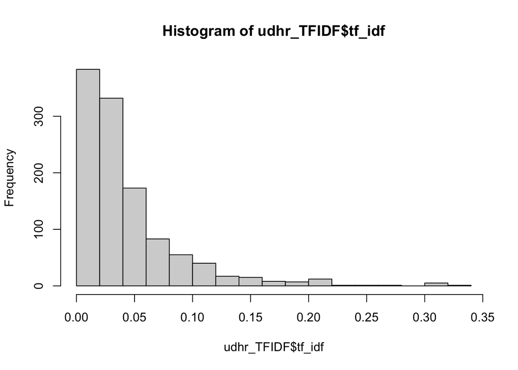

```r
hist(udhr_TFIDF$tf_idf)
```

Let’s take a look at any of the Articles:

```r
articleID = "Article 26"
temp <- filter(udhr_TFIDF, SECTION==articleID) %>%
  arrange(desc(tf_idf))

temp
```

| SECTION | WORD | n | tf | idf | tf_idf |
| --- | --- | --- | --- | --- | --- |
| Article 26 | education | 7 | 0.058823529 | 2.74084002 | 0.161225884 |
| Article 26 | elementary | 2 | 0.016806723 | 3.43398720 | 0.057714071 |
| Article 26 | shall | 8 | 0.067226891 | 0.79492987 | 0.053440664 |
| Article 26 | fundamental | 2 | 0.016806723 | 2.04769284 | 0.034415006 |
| Article 26 | human | 2 | 0.016806723 | 2.04769284 | 0.034415006 |
| Article 26 | nations | 2 | 0.016806723 | 2.04769284 | 0.034415006 |
| Article 26 | be | 6 | 0.050420168 | 0.60077386 | 0.030291119 |
| Article 26 | accessible | 1 | 0.008403361 | 3.43398720 | 0.028857035 |
| Article 26 | activities | 1 | 0.008403361 | 3.43398720 | 0.028857035 |
| Article 26 | available | 1 | 0.008403361 | 3.43398720 | 0.028857035 |

[output cut: 59 more lines]

We can use wordcloud to vizualize results — but they will not be too telling, if we use word frequencies.

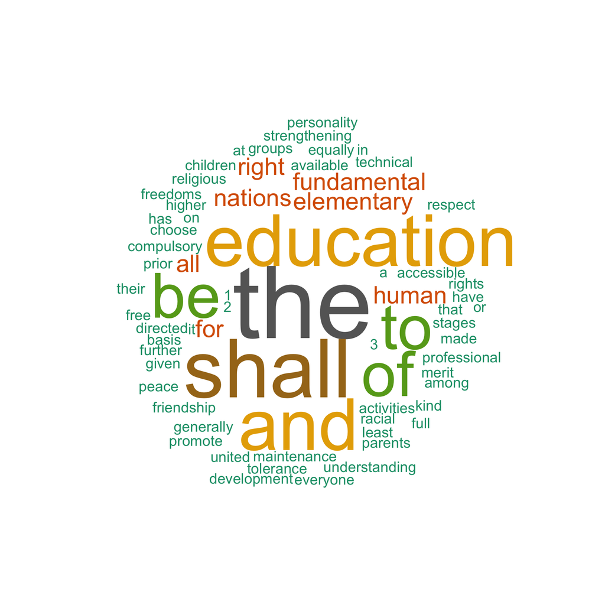

```r
library(wordcloud)
library("RColorBrewer")

set.seed(1234)
wordcloud(words=temp$WORD, freq=temp$n,
          min.freq = 1, rot.per = .0, random.order=FALSE, scale=c(10,.5),
          max.words=150, colors=brewer.pal(8, "Dark2"))
```

Instead we can use `tf_idf` values:

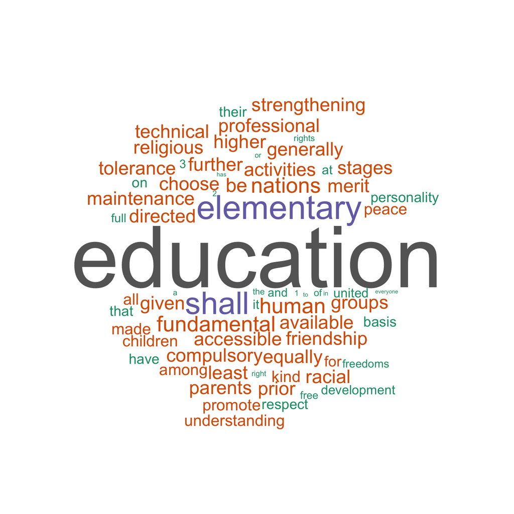

```r
set.seed(1234)
wordcloud(words=temp$WORD, freq=temp$tf_idf,
          min.freq = 1, rot.per = .0, random.order=FALSE, scale=c(10,.5),
          max.words=150, colors=brewer.pal(8, "Dark2"))
```

## 4.1 Inaugural speeches of the US presidents

The `quanteda` package includes a corpus of presidential inaugural speeches. What did the presidenst speak about?

```r
data("data_corpus_inaugural", package = "quanteda")
inaug_dfm <- quanteda::dfm(data_corpus_inaugural, verbose = FALSE)
head(inaug_dfm)
```

```
## Document-feature matrix of: 6 documents, 9,360 features (93.8% sparse) and 4 docvars.
##                  features
## docs              fellow-citizens  of the senate and house representatives :
##   1789-Washington               1  71 116      1  48     2               2 1
##   1793-Washington               0  11  13      0   2     0               0 1
##   1797-Adams                    3 140 163      1 130     0               2 0
##   1801-Jefferson                2 104 130      0  81     0               0 1
##   1805-Jefferson                0 101 143      0  93     0               0 0
##   1809-Madison                  1  69 104      0  43     0               0 0
##                  features
## docs              among vicissitudes
##   1789-Washington     1            1
##   1793-Washington     0            0
##   1797-Adams          4            0
##   1801-Jefferson      1            0
##   1805-Jefferson      7            0
##   1809-Madison        0            0
## [ reached max_nfeat ... 9,350 more features ]
```

The corpus is stored as a `document-feature matrix`, which we can convert into a more familiar tidy format in the following manner:

```r
inaug_td <- tidy(inaug_dfm)
head(inaug_td)
```

| document | term | count |
| --- | --- | --- |
| 1789-Washington | fellow-citizens | 1 |
| 1797-Adams | fellow-citizens | 3 |
| 1801-Jefferson | fellow-citizens | 2 |
| 1809-Madison | fellow-citizens | 1 |
| 1813-Madison | fellow-citizens | 1 |
| 1817-Monroe | fellow-citizens | 5 |

3. Using what you have learned so far, analyze speeches of American presidents:

# 5 Text summarization

Before we proceed, let’s load some text. Below is an example of how you can load a text using its URL. However, be mindful about using this approach: it is convenient with a small number of short texts, but not efficient with large number of long texts.

```r
urlText <- "https://univie-histr-2020s.github.io/files/test_text.txt"
testText <- scan(url(urlText), what="character", sep="\n")
```

We can use dfferent algorithms to *summarize* texts, which in this context means extracting key sentences, whose keyness is calculated through different means. Library `lexRankr` used tf-idf values and some methods from social network analysis to identify the most central sentences in a text. (For technical details, see: https://cran.r-project.org/web/packages/lexRankr/lexRankr.pdf; for a detailed *math* description: http://www.cs.cmu.edu/afs/cs/project/jair/pub/volume22/erkan04a-html/erkan04a.html).

Take a look at the summary and then at the full text!

```r
library(lexRankr)
textToSummarize = testText

summary = lexRank(textToSummarize,
                  docId = rep(1, length(textToSummarize)), #repeat same docid for all of input vector
                  n = 5, # number of sentences
                  continuous = TRUE)
```

```
## Parsing text into sentences and tokens...DONE
## Calculating pairwise sentence similarities...DONE
## Applying LexRank...DONE
## Formatting Output...DONE
```

```r
# this is just preparing results for better viewing
summary$sentenceId <- str_replace_all(summary$sentenceId, "\\d+_", "")
summary$sentenceId <- as.numeric(summary$sentenceId)

summary <- summary %>%
  arrange(sentenceId)

summary$sentence
```

```
## [1] "The Klimt University of Vienna Ceiling Paintings, also known as the Faculty Paintings, were a series of paintings made by Gustav Klimt for the ceiling of the University of Vienna`s Great Hall between the years of 1900–1907."
## [2] "Upon presenting his paintings, Philosophy, Medicine and Jurisprudence, Klimt came under attack for `pornography` and `perverted excess` in the paintings."
## [3] "Klimt described the painting as follows: `On the left a group of figures, the beginning of life, fruition, decay."
## [4] "In 1903, Hermann Bahr, a writer and a supporter of Klimt, in response to the criticism of the Faculty Paintings compiled articles which attacked Klimt, and published a book Gegen Klimt (Against Klimt) with his foreword, where he argued that the reactions were absurd."
## [5] "In 1911 Medicine and Jurisprudence were bought by Klimt`s friend and fellow artist, Koloman Moser.[clarification needed] Medicine eventually came into the possession of a Jewish family, and in 1938 the painting was seized by Germany."
```